# My R Markdown Prime

2025-11-16

## R Markdown

R Markdown is a tool that lets you combine text, R code, and math in one document. When you knit the file, R Markdown runs the code and creates a clean report. This makes it easier to keep your analysis organized and up to date, and it ensures that your results always match the code you’ve written. R Markdown also let’s you include LaTeX math expressions, which makes presenting formulas and calculations much clearer.

# Narrtive

One thing I really like about R Markdown is that I can write my explanations and show my code all in one place. If I update the dataset or change the code, the results and plots automatically refresh when I knit the file, which keeps everything consistent without having to copy and paste. I also like how it blends text, visuals, and code so smoothly it makes my work look more organized and easier for others to follow.

## LaTeX Math Examples

Displayed equation:

$$E = mc^2$$

```r
library(ggplot2)
data("mtcars")
head(mtcars)
```

```
##                    mpg cyl disp  hp drat    wt  qsec vs am gear carb
## Mazda RX4         21.0   6  160 110 3.90 2.620 16.46  0  1    4    4
## Mazda RX4 Wag     21.0   6  160 110 3.90 2.875 17.02  0  1    4    4
## Datsun 710        22.8   4  108  93 3.85 2.320 18.61  1  1    4    1
## Hornet 4 Drive    21.4   6  258 110 3.08 3.215 19.44  1  0    3    1
## Hornet Sportabout 18.7   8  360 175 3.15 3.440 17.02  0  0    3    2
## Valiant           18.1   6  225 105 2.76 3.460 20.22  1  0    3    1
```

```r
summary(mtcars$mpg)
```

```
##    Min. 1st Qu.  Median    Mean 3rd Qu.    Max.
##   10.40   15.43   19.20   20.09   22.80   33.90
```

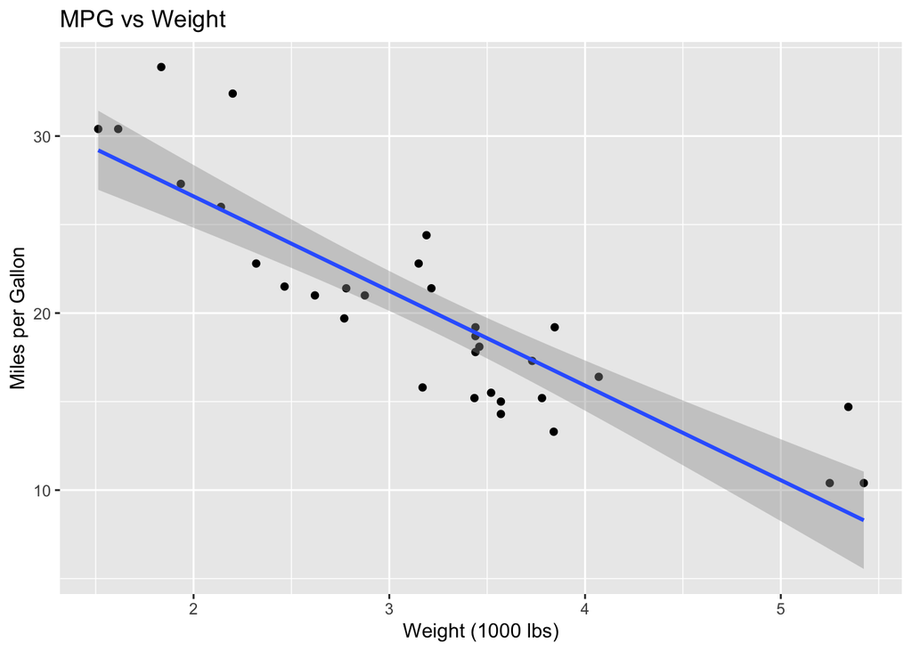

```r
ggplot(mtcars, aes(x = wt, y = mpg)) +
geom_point() +
geom_smooth(method = "lm") +
labs(title = "MPG vs Weight",
x = "Weight (1000 lbs)",
y = "Miles per Gallon")
```

# Reflection

Using R Markdown felt really different from writing a regular report, but in a good way. I liked having my text, code, math, and graphs all in the same place instead of switching between programs. It also saved time because everything updates automatically when the code runs. When I compared my .Rmd file to the knitted HTML, I was surprised by how clean and organized the final report turned out. I liked how simple it was to add things like math formulas and plots with just a few lines of code. Overall, R Markdown made the whole reporting process easier, cleaner, and more organized.